## Assignment 1:

### 2.

Fork the course repository. Create a directory called Test. Add a markdown file to your Test directory called readme.md. Edit the readme file using markdown syntax to include a description of what you’ve done. Create screenshots to show what you’ve done and hand in the screenshots.

- question2.png

[figure not shown]

question2.png

### 3.

Issue a pull request for the course repository. Create a screenshot of your pull request. Hand in the screenshot.

- question3.png

[figure not shown]

question3.png

### 4.

Create a new github repository called ds4bmeTest; add a readme.md file. Create screenshots to show your work and hand those in.

- question4.png

[figure not shown]

question4.png

### 5.

Download or create a simple webpage; commit it to your repository and serve the webpage using github pages. Create screenshot and hand those in.

- [This is a link](https://luchaoqi.github.io/)
- question5.png

[figure not shown]

question5.png

### 6.

Write a bash script lsfile of the form lsfile path outfile that outputs the output of the command ls path to the file outfile.

> Check the scipt I uploaded.
- question6.png

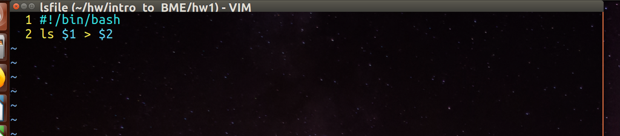

question6.png

### 7.

Write a script that recurses directories for all files with the extension .dcm and outputs them to a file.

> Check the scipt I uploaded. I chose the current directory and could be changed to any other directories by changing “.” to targeted directory. Or use the method same as Question6.
- question7.png

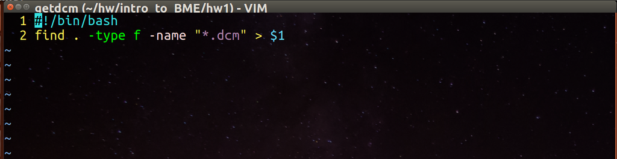

question7.png

### 8.

Using unix, grab the wikipedia page for Alexander the Great. Use the linux commands to count the number of lines in the file.

> 3547
- question8.png

[figure not shown]

question8.png